# yelp_reviews

Huey

June 20, 2016

# Introduction

Are there differences in rating restaurants among different ethnicities? For instance, perhaps Chinese people rate Chinese restaurants differently from other Americans (presumably based on authenticity). If so, building a “racist Yelp” could be useful for identifying more authetnic restaurants.

Here we look at the Yelp dataset to try to tease out any differences, looking at Mexican and East Asian restaurants.

### Data

The Yelp data contains 2.2M reviews and 591K tips by 552K users for 77K businesses.

The cities included are Edinburgh (UK), Karlsruhe (Germany), Montreal and Waterloo (Canada), and Pittsburgh, Charlotte, Urbana-Champaign, Phoenix, Las Vegas, Madison (US).

I used the JSON to CSV converter in https://github.com/Yelp/dataset-examples to make it easier to load.

We use a list of popular Latino names pulled from http://www.1happybirthday.com/popular_names_latino.php. We classify a user as Latino if their name appears in this list.

```r
businesses = read_csv("data/yelp_academic_dataset_business.csv")
reviews = read_csv("data/yelp_academic_dataset_review.csv")
users = read_csv("data/yelp_academic_dataset_user.csv")
users$name = tolower(users$name)

latino.names = read.csv("popular_names_latino.csv",
                        encoding = "latin1", stringsAsFactors = FALSE)
latino.names$Male.Name = stri_trans_general(latino.names$Male.Name,
                                            'latin-ascii')
latino.names$Female.Name = stri_trans_general(latino.names$Female.Name,
                                              'latin-ascii')

latino.names = as.data.frame(c(latino.names$Male.Name, latino.names$Female.Name), stringsAsFactors = FALSE)
names(latino.names) = "name"

latino.names.exclude = read.csv("popular_names_latino_exclude.csv", stringsAsFactors = FALSE)

latino.names = anti_join(latino.names, latino.names.exclude, by = "name")
latino.names$name = tolower(latino.names$name)
```

When classifying ethnicity, it’s good to get a rough sense of how many users were classified as Latino or not:

```r
latino.users = semi_join(users, latino.names, by = "name")
non.latino.users = anti_join(users, latino.names, by = "name")

print(paste("Latino:", nrow(latino.users)))
```

```
## [1] "Latino: 14987"
```

```r
print(paste("Non-Latino:" , nrow(non.latino.users)))
```

```
## [1] "Non-Latino: 537352"
```

Less than 3% of users in the dataset have been classified as Latino. There are probably more Latino users in the dataset who have names of European origin, but since Yelp only gives us access to first names, this is probably the best we can do at the moment.

Below is a function to get all the top n restaurants of a certain ethnicity and bucket the user reviews into members of that ethnicity or not. We then run a t-test applying the Bonferroni correction to find which differences are statistically significant.

```r
GetRestaurantsWithDiffRatings = function(ethnicity, n.restaurants, eth.names) {
  eth.restaurants = businesses %>% filter(grepl(ethnicity, categories)) %>% filter(grepl('Restaurants', categories)) %>% arrange(desc(review_count))
  restaurants = eth.restaurants[1:n.restaurants, ]
  restaurant.reviews = inner_join(restaurants, reviews, by = "business_id")
  restaurant.reviews.users = inner_join(restaurant.reviews, users, by = "user_id")

  p.value.cutoff = 0.05 / n.restaurants

  restaurant_names = c()
  eth.ratings = c()
  non.eth.ratings = c()
  num.eth.reviews = c()
  num.non.eth.reviews = c()

  for (id in restaurants$business_id) {
    subset = filter(restaurant.reviews.users, business_id == id)
    eth.reviews = semi_join(subset, eth.names, c("name.y" = "name"))
    non.eth.reviews = anti_join(subset, eth.names, c("name.y" = "name"))

    if (length(eth.reviews$stars.y) <= 1 || length(non.eth.reviews$stars.y) <= 1) next  # Prevent errors to t-test

    try({
      alt = "two.sided"
      eth.mean = mean(eth.reviews$stars.y)
      non.eth.mean = mean(non.eth.reviews$stars.y)
      if (eth.mean < non.eth.mean) {
        alt = "less"
      }
      if (eth.mean > non.eth.mean) {
        alt = "greater"
      }
      res = t.test(eth.reviews$stars.y, non.eth.reviews$stars.y, alternative = alt)
      if (res$p.value < p.value.cutoff) {
        restaurant_names = c(restaurant_names, subset$name.x[1])
        eth.ratings = c(eth.ratings, eth.mean)
        non.eth.ratings = c(non.eth.ratings, non.eth.mean)
        num.eth.reviews = c(num.eth.reviews, nrow(eth.reviews))
        num.non.eth.reviews = c(num.non.eth.reviews, nrow(non.eth.reviews))
      }
    }
    )
  }
  return(data.frame(restaurant_names, eth.ratings, non.eth.ratings, num.eth.reviews, num.non.eth.reviews))
}
```

## Mexican Restaurants

The following table shows the restaurants where Latino ratings and non-Latino ratings had statistically significant differences:

```r
results = GetRestaurantsWithDiffRatings('Mexican', 100, latino.names)
results
```

```
##                 restaurant_names eth.ratings non.eth.ratings
## 1                       Javier's      4.5625        3.811508
## 2 Vida Mexican Kitchen y Cantina      4.0000        3.421053
## 3          Diego Mexican Cuisine      5.0000        3.470852
## 4                    Two Hippies      5.0000        3.733607
##   num.eth.reviews num.non.eth.reviews
## 1              16                 504
## 2               3                 266
## 3               4                 223
## 4               2                 244
```

For all of these, the sample size of Latino reviews is really small. It seems that building a “racist Yelp” for Mexican restaurants would not be all that useful.

## Chinese Restaurants

To get Chinese-sounding names, we will compile a list of all pinyin sounds and see if they exist in any first names. This runs in quadratic time, so we save the users who matched.

```r
load(file = "chinese.users.RData")

if (is.null(chinese.users)) {
  pinyin = read.csv("pinyin_sounds.csv", stringsAsFactors = FALSE)
  pinyin.pattern = paste(pinyin$sound, collapse ="|")

  exclude = "benji|ique|cque|arjun|axi|lexi|xine|jinx|quant|change|strong|cruise|chunky|suite|burgh fan|tx fan|eping|pping|lping"

  tictoc::tic()
  indexes = vector("logical", length = nrow(users))
  for (i in 1:nrow(users)) {
    if (length(grep(exclude, users$name[i])) > 0) next

    matches = grep(pinyin.pattern, users$name[i])
    indexes[i] = length(matches) > 0
  }
  tictoc::toc()
  chinese.users = users[indexes,]
  nrow(chinese.users)

  # save chinese.users in case it takes a long time
  save(chinese.users, file = "chinese.users.RData")
}

chinese.names = as.data.frame(unique(chinese.users$name), stringsAsFactors = FALSE)
names(chinese.names) = "name"
set.seed(1)
sample_n(chinese.names, 10)
```

```
##           name
## 870    bunjies
## 1219     jiali
## 1875  miyishia
## 2972  donghwan
## 660     zhenya
## 2938 foodsmurf
## 3089  yosafena
## 2160    murphi
## 2056      zong
## 202     shu ju
```

There are 7755 users classified as Chinese, or about 1.4% of the user population. Sanity checking: Americans of Chinese descent consititute 1.2% of the total U.S. popuplation as of 2010.

You can see from the sample that some of the names look more obviously Chinese than not. This suggests that we probably classified too many names as Chinese, as it is likely that many Chinese users of Yelp have Western first names.

```r
results = GetRestaurantsWithDiffRatings('Chinese', 100, chinese.names)
names(results) = c("name", "chinese_ratings", "non_chinese_ratings", "n_chinese", "n_non_chinese")
results
```

```
##                                 name chinese_ratings non_chinese_ratings
## 1                       P.F. Chang's        5.000000            3.370968
## 2 Ling & Louie's Asian Bar and Grill        2.000000            3.880682
## 3                    Sichuan Gourmet        4.636364            3.784000
##   n_chinese n_non_chinese
## 1         2           186
## 2         2           176
## 3        22           125
```

Only 3 restaurants have statistically different ratings, and two of them only have 2 Chinese reviews!

## Chinese Names Take 2

An alternative is to use the baby names from the following site: http://www.top-100-baby-names-search.com/chinese-name-meanings.html

```r
chinese.names2 = read.csv("top_100_baby_names_chinese.csv", stringsAsFactors = FALSE)
chinese.names2$name = tolower(chinese.names2$name)
chinese.names2 = chinese.names2[-124,]  # remove "juan"
chinese.users2 = semi_join(users, chinese.names2, by = "name")

results = GetRestaurantsWithDiffRatings('Chinese', 100, chinese.names2)
names(results) = c("name", "chinese_ratings", "non_chinese_ratings", "n_chinese", "n_non_chinese")
results
```

```
##                   name chinese_ratings non_chinese_ratings n_chinese
## 1       Ping Pang Pong               4            3.546809         5
## 2         Veggie House               5            4.541950         2
## 3 KJ Dim Sum & Seafood               5            3.394928         2
## 4       Chou's Kitchen               5            4.029268         3
## 5           Noodle Pot               5            3.685393         2
##   n_non_chinese
## 1           470
## 2           441
## 3           276
## 4           205
## 5           178
```

This yielded 2028 users and a different set of restaurants that had statistically significantly different ratings. However, the number of reviews by Chinese people are still too low to make any significant conclusions.

## East Asian Restaurants

What if we expand our search to Korean + Japanese + Chinese? Here we just use the baby names list for Chinese names.

```r
korean.names = read.csv("top_100_baby_names_korean.csv", stringsAsFactors = FALSE)
korean.names$name = tolower(korean.names$name)

japanese.names = read.csv("top_100_baby_names_japanese.csv", stringsAsFactors = FALSE)
japanese.names$name = tolower(japanese.names$name)

korean.users = semi_join(users, korean.names, by = "name")
japanese.users = semi_join(users, japanese.names, by = "name")

east.asian.names = as.data.frame(c(chinese.names2$name, japanese.names$name, korean.names$name), stringsAsFactors = FALSE)
names(east.asian.names) = c("name")
east.asian.users = semi_join(users, east.asian.names, by = "name")

results = GetRestaurantsWithDiffRatings('Chinese|Korean|Japanese', 100, east.asian.names)
names(results) = c("name", "asian_ratings", "non_asian_ratings", "n_asian", "n_non_asian")
results
```

```
##                         name asian_ratings non_asian_ratings n_asian
## 1   Gangnam Asian BBQ Dining      4.872727          4.667679      55
## 2             Ping Pang Pong      4.000000          3.544872       7
## 3               Veggie House      5.000000          4.541950       2
## 4 Kabuki Japanese Restaurant      4.000000          3.495957       3
## 5                  Makino LV      4.857143          3.697595       7
## 6           Tonkatsu Kiyoshi      5.000000          4.524904       3
##   n_non_asian
## 1        1646
## 2         468
## 3         441
## 4         371
## 5         291
## 6         261
```

The only restaurant that has more than 10 East Asian reviews is Gangnam Asian BBQ Dining. Its rating among Asians is slightly higher.

## East Asian Users using pinyin for Chinese names

```r
east.asian.names = as.data.frame(c(chinese.names$name, japanese.names$name, korean.names$name), stringsAsFactors = FALSE)
names(east.asian.names) = c("name")
east.asian.users = semi_join(users, east.asian.names, by = "name")

results = GetRestaurantsWithDiffRatings('Chinese|Korean|Japanese', 100, east.asian.names)
results
```

```
##   restaurant_names eth.ratings non.eth.ratings num.eth.reviews
## 1        Makino LV    4.777778        3.692042               9
## 2         Japonais    2.000000        3.532319               3
##   num.non.eth.reviews
## 1                 289
## 2                 263
```

Again, nothing terribly interesting here.

# Conclusion

You can’t construct a good “racist Yelp” from the data provided. If we had a better way of classifying the race of users, we might be able to get better results.

## Restaurant preferences

What kind of restaurants do Latinos review? What kind of restaurants do Asians review?

What’s the distribution of review count on yelp?

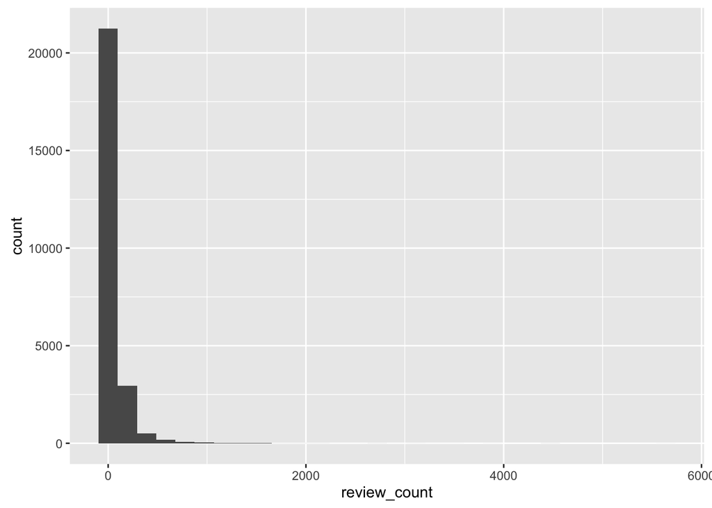

```r
bw = function(x) diff(range(x)) / (2 * IQR(x) / length(x)^(1/3))
restaurants = businesses %>% filter(grepl('Restaurants', categories)) %>% arrange(desc(review_count))
ggplot(restaurants, aes(x = review_count)) + geom_histogram()
```

This seems in line with what we expect. The vast majority of restaurants have a few reviews, with a long tail – some restaurants have many more reviews.

Here is some code to group reviews by ethnicity.

```r
ReviewCountsForEthnicity = function(eth.names) {
  eth.users = semi_join(users, eth.names, by = "name")
  non.eth.users = anti_join(users, eth.names, by = "name")

  restaurant.reviews = inner_join(restaurants, reviews, by = "business_id")
  restaurant.reviews.eth.users = inner_join(restaurant.reviews, eth.users, by = "user_id")
  restaurant.reviews.non.eth.users = inner_join(restaurant.reviews, non.eth.users, by = "user_id")

  by.restaurant = group_by(restaurant.reviews.eth.users, business_id)
  eth.summary = summarise(by.restaurant, num.reviews = n())
  eth.summary = inner_join(eth.summary, restaurants, by = "business_id") %>% select(business_id, name, num.reviews, categories)

  by.restaurant = group_by(restaurant.reviews.non.eth.users, business_id)
  non.eth.summary = summarise(by.restaurant, num.reviews = n()) %>% arrange(desc(num.reviews))
  non.eth.summary = inner_join(non.eth.summary, restaurants, by = "business_id") %>% select(business_id, name, num.reviews, categories)

  return(list(eth.summary, non.eth.summary))
}
```

```r
CompileStats = function(names, n) {
  l = list()
  summaries = ReviewCountsForEthnicity(names)

  n.eth.summaries = head(summaries[[1]] %>% arrange(desc(num.reviews)), n)
  l[[1]] = n.eth.summaries

  n.non.eth.summaries = head(summaries[[2]] %>% arrange(desc(num.reviews)) , n)
  l[[2]] = n.non.eth.summaries

  l[[3]] = semi_join(n.eth.summaries, n.non.eth.summaries, by = "business_id")
  l[[4]] = anti_join(n.eth.summaries, n.non.eth.summaries, by = "business_id")
  l[[5]] = anti_join(n.non.eth.summaries, n.eth.summaries, by = "business_id")

  return(l)
}
```

This is a utlity function to count the categories of a set of restaurants.

```r
MakeCategoriesDict = function(categories) {
  category.map = hash()
  # category.map[["key"]]
  for (category.string in categories) {
    str = gsub("\'|\\[|\\]", '', category.string)
    category.list = unlist(strsplit(str, ", "))
    for (category in category.list) {
      count = category.map[[category]]
      if (is.null(count)) {
        category.map[[category]] = 1
      } else {
        category.map[[category]] = count + 1
      }
    }
  }
  del('Restaurants', category.map)  # All the Restaurants have this category, so it's useless.
  return(category.map)
}
```

Top 100 restaurants among Latinos, based on number of reviews:

```r
n = 100
latinos = CompileStats(latino.names, n)
latinos[[1]] %>% select(name, num.reviews)
```

```
## Source: local data frame [100 x 2]
##
##                   name num.reviews
##                  (chr)       (int)
## 1         Mon Ami Gabi         121
## 2     Earl of Sandwich          92
## 3  Gordon Ramsay BurGR          89
## 4     Bacchanal Buffet          86
## 5        Serendipity 3          83
## 6         Secret Pizza          70
## 7         Wicked Spoon          70
## 8   Hash House A Go Go          68
## 9   Hash House A Go Go          65
## 10   El Dorado Cantina          64
## ..                 ...         ...
```

Category counts:

```r
sort(values(MakeCategoriesDict(latinos[[1]]$categories)), decreasing = TRUE)
```

```
##                 Nightlife                      Bars
##                        20                        19
##            American (New)    American (Traditional)
##                        18                        15
##        Breakfast & Brunch                   Buffets
##                        15                        10
##                   Mexican                      Food
##                        10                         9
##               Steakhouses                Sandwiches
##                         9                         7
##                   Burgers                   Italian
##                         6                         6
##                  Japanese                     Pizza
##                         6                         5
##                Sushi Bars                  Barbeque
##                         5                         4
##              Coffee & Tea                   Seafood
##                         4                         4
##        Tapas/Small Plates      Arts & Entertainment
##                         4                         3
##              Asian Fusion                    French
##                         3                         3
##                   Lounges                Tapas Bars
##                         3                         3
##                 Brazilian                 Breweries
##                         2                         2
##                   Casinos                   Chinese
##                         2                         2
##                  Desserts                    Korean
##                         2                         2
##            Latin American                      Pubs
##                         2                         2
##                 Soul Food                  Southern
##                         2                         2
##                   Spanish                      Thai
##                         2                         2
##                     Vegan                Vietnamese
##                         2                         2
##                 Wine Bars                  Bakeries
##                         2                         1
##                      Beer                   British
##                         1                         1
##                     Cafes              Cajun/Creole
##                         1                         1
##                 Caribbean             Cocktail Bars
##                         1                         1
##                     Delis Event Planning & Services
##                         1                         1
##                 Fast Food                Gastropubs
##                         1                         1
##                  Hot Dogs             Mediterranean
##                         1                         1
##              Music Venues                     Ramen
##                         1                         1
##                Vegetarian                Venezuelan
##                         1                         1
##     Venues & Event Spaces            Wine & Spirits
##                         1                         1
```

Mostly Nightlife, Bars, American Food.

Top 100 restaurants among non-Latinos, based on number of reviews

```r
latinos[[2]] %>% select(name, num.reviews)
```

```
## Source: local data frame [100 x 2]
##
##                       name num.reviews
##                      (chr)       (int)
## 1             Mon Ami Gabi        4921
## 2             Wicked Spoon        3888
## 3         Earl of Sandwich        3804
## 4         Bacchanal Buffet        3702
## 5      Gordon Ramsay BurGR        3316
## 6            Serendipity 3        3003
## 7               The Buffet        2820
## 8       Hash House A Go Go        2636
## 9  Bouchon at The Venetian        2547
## 10  The Buffet at Bellagio        2514
## ..                     ...         ...
```

Category counts:

```r
sort(values(MakeCategoriesDict(latinos[[2]]$categories)), decreasing = TRUE)
```

```
##                      Bars                 Nightlife
##                        25                        25
##            American (New)    American (Traditional)
##                        22                        16
##        Breakfast & Brunch               Steakhouses
##                        14                        14
##                   Buffets                   Burgers
##                        10                         9
##                      Food                   Mexican
##                         8                         8
##                   Lounges                   Italian
##                         7                         6
##                  Japanese                Sandwiches
##                         6                         6
##              Asian Fusion                     Pizza
##                         5                         5
##                    French                   Seafood
##                         4                         4
##                Sushi Bars                  Barbeque
##                         4                         3
##                   Chinese             Mediterranean
##                         3                         3
##      Arts & Entertainment                  Bakeries
##                         2                         2
##                 Breweries                   Casinos
##                         2                         2
##              Coffee & Tea                  Desserts
##                         2                         2
##                Gastropubs                    Korean
##                         2                         2
##                      Pubs                     Salad
##                         2                         2
##                 Soul Food                  Southern
##                         2                         2
##                Tapas Bars        Tapas/Small Plates
##                         2                         2
##                 Wine Bars                      Beer
##                         2                         1
##                 Brazilian                   British
##                         1                         1
##                     Cafes              Cajun/Creole
##                         1                         1
##             Cocktail Bars                     Delis
##                         1                         1
## Event Planning & Services                    German
##                         1                         1
##            Latin American                     Ramen
##                         1                         1
##                   Spanish                  Szechuan
##                         1                         1
##                      Thai                Vegetarian
##                         1                         1
##     Venues & Event Spaces                Vietnamese
##                         1                         1
##            Wine & Spirits
##                         1
```

Mostly Nightlife, Bars, American Food.

Comparing the two sets, which restaurants are in common?

```r
latinos[[3]] %>% select(name, num.reviews)
```

```
## Source: local data frame [75 x 2]
##
##                       name num.reviews
##                      (chr)       (int)
## 1             Mon Ami Gabi         121
## 2             Wicked Spoon          70
## 3         Earl of Sandwich          92
## 4         Bacchanal Buffet          86
## 5      Gordon Ramsay BurGR          89
## 6            Serendipity 3          83
## 7               The Buffet          56
## 8       Hash House A Go Go          68
## 9  Bouchon at The Venetian          42
## 10  The Buffet at Bellagio          62
## ..                     ...         ...
```

75%!

Category counts:

```r
sort(values(MakeCategoriesDict(latinos[[3]]$categories)), decreasing = TRUE)
```

```
##                      Bars                 Nightlife
##                        17                        17
##    American (Traditional)            American (New)
##                        14                        13
##        Breakfast & Brunch                   Buffets
##                        11                        10
##               Steakhouses                      Food
##                         8                         7
##                   Mexican                Sandwiches
##                         7                         6
##                   Burgers                   Italian
##                         5                         4
##                     Pizza              Asian Fusion
##                         4                         3
##                  Barbeque                    French
##                         3                         3
##                  Japanese                   Lounges
##                         3                         3
##                   Seafood      Arts & Entertainment
##                         3                         2
##                 Breweries                   Casinos
##                         2                         2
##                   Chinese              Coffee & Tea
##                         2                         2
##                  Desserts                    Korean
##                         2                         2
##                      Pubs                 Soul Food
##                         2                         2
##                  Southern                Sushi Bars
##                         2                         2
##                Tapas Bars        Tapas/Small Plates
##                         2                         2
##                  Bakeries                      Beer
##                         1                         1
##                 Brazilian                   British
##                         1                         1
##              Cajun/Creole             Cocktail Bars
##                         1                         1
##                     Delis Event Planning & Services
##                         1                         1
##                Gastropubs            Latin American
##                         1                         1
##             Mediterranean                     Ramen
##                         1                         1
##                   Spanish                      Thai
##                         1                         1
##     Venues & Event Spaces                Vietnamese
##                         1                         1
##            Wine & Spirits                 Wine Bars
##                         1                         1
```

Bars, Nightlife, American food.

Restaurants that are popular among Latinos but not among non-Latinos:

```r
latinos[[4]] %>% select(name, num.reviews)
```

```
## Source: local data frame [25 x 2]
##
##                      name num.reviews
##                     (chr)       (int)
## 1          Carson Kitchen          23
## 2         Pink's Hot Dogs          23
## 3          Joe's Real BBQ          23
## 4         Postino Central          23
## 5              Sushi Kaya          24
## 6        Culinary Dropout          24
## 7          Sunrise Coffee          24
## 8             Bronze Cafe          24
## 9  Yonaka Modern Japanese          24
## 10             The Parlor          25
## ..                    ...         ...
```

Category counts:

```r
sort(values(MakeCategoriesDict(latinos[[4]]$categories)), decreasing = TRUE)
```

```
##         American (New)     Breakfast & Brunch               Japanese
##                      5                      4                      3
##                Mexican              Nightlife             Sushi Bars
##                      3                      3                      3
##                   Bars           Coffee & Tea                   Food
##                      2                      2                      2
##                Italian     Tapas/Small Plates                  Vegan
##                      2                      2                      2
## American (Traditional)   Arts & Entertainment               Barbeque
##                      1                      1                      1
##              Brazilian                Burgers                  Cafes
##                      1                      1                      1
##              Caribbean              Fast Food               Hot Dogs
##                      1                      1                      1
##         Latin American           Music Venues                  Pizza
##                      1                      1                      1
##             Sandwiches                Seafood                Spanish
##                      1                      1                      1
##            Steakhouses             Tapas Bars                   Thai
##                      1                      1                      1
##             Vegetarian             Venezuelan             Vietnamese
##                      1                      1                      1
##              Wine Bars
##                      1
```

Hard to see, a little bit of Mexican food.

Vice-versa:

```r
latinos[[5]] %>% select(name, num.reviews)
```

```
## Source: local data frame [25 x 2]
##
##                        name num.reviews
##                       (chr)       (int)
## 1       Mastro's Ocean Club         825
## 2    Amélie's French Bakery         829
## 3                       MIX         835
## 4    Yard House Town Square         837
## 5                       CUT         844
## 6                Echo & Rig         853
## 7                      Raku         854
## 8      Rehab Burger Therapy         862
## 9                 Carnevino         881
## 10 Soho Japanese Restaurant         882
## ..                      ...         ...
```

```r
sort(values(MakeCategoriesDict(latinos[[5]]$categories)), decreasing = TRUE)
```

```
##         American (New)                   Bars              Nightlife
##                      9                      8                      8
##            Steakhouses                Burgers                Lounges
##                      6                      4                      4
##     Breakfast & Brunch               Japanese American (Traditional)
##                      3                      3                      2
##           Asian Fusion                Italian          Mediterranean
##                      2                      2                      2
##                  Salad             Sushi Bars               Bakeries
##                      2                      2                      1
##                  Cafes                Chinese                   Food
##                      1                      1                      1
##                 French             Gastropubs                 German
##                      1                      1                      1
##                Mexican                  Pizza                Seafood
##                      1                      1                      1
##               Szechuan             Vegetarian              Wine Bars
##                      1                      1                      1
```

## Similar analysis but for East Asians

Top 100 restaurants among East Asians, based on number of reviews:

```r
asians = CompileStats(east.asian.names, n)
asians[[1]] %>% select(name, num.reviews)
```

```
## Source: local data frame [100 x 2]
##
##                        name num.reviews
##                       (chr)       (int)
## 1  Gangnam Asian BBQ Dining         154
## 2              Wicked Spoon         121
## 3          Bacchanal Buffet         118
## 4          Earl of Sandwich         104
## 5              Mon Ami Gabi         101
## 6                The Buffet          89
## 7    The Buffet at Bellagio          75
## 8               Monta Ramen          73
## 9       Gordon Ramsay BurGR          67
## 10            Lotus of Siam          63
## ..                      ...         ...
```

Category counts:

```r
sort(values(MakeCategoriesDict(asians[[1]]$categories)), decreasing = TRUE)
```

```
##                  Japanese                   Buffets
##                        17                        13
##                      Bars                   Chinese
##                        12                        12
##                 Nightlife            American (New)
##                        12                         9
##    American (Traditional)        Breakfast & Brunch
##                         9                         9
##                Sushi Bars              Asian Fusion
##                         9                         8
##                    Korean                   Seafood
##                         7                         7
##               Steakhouses                      Food
##                         7                         6
##                    French                   Lounges
##                         5                         5
##                  Barbeque                   Burgers
##                         4                         4
##                Vietnamese              Coffee & Tea
##                         4                         3
##                  Desserts                   Dim Sum
##                         3                         3
##                    Indian                   Mexican
##                         3                         3
##                Sandwiches                      Thai
##                         3                         3
##              Cajun/Creole                   Italian
##                         2                         2
##                     Ramen                  Szechuan
##                         2                         2
##                Tapas Bars      Arts & Entertainment
##                         2                         1
##                 Breweries                     Cafes
##                         1                         1
##            Canadian (New)                 Cantonese
##                         1                         1
##                   Casinos                     Delis
##                         1                         1
## Event Planning & Services             Mediterranean
##                         1                         1
##                     Pizza               Poutineries
##                         1                         1
##                  Southern                   Spanish
##                         1                         1
##                 Taiwanese        Tapas/Small Plates
##                         1                         1
##                Vegetarian     Venues & Event Spaces
##                         1                         1
```

Japanese, Buffets, Bars, Chinese, Nightlife

Top 100 restaurants among non-East Asians:

```r
asians[[2]] %>% select(name, num.reviews)
```

```
## Source: local data frame [100 x 2]
##
##                       name num.reviews
##                      (chr)       (int)
## 1             Mon Ami Gabi        4941
## 2             Wicked Spoon        3837
## 3         Earl of Sandwich        3792
## 4         Bacchanal Buffet        3670
## 5      Gordon Ramsay BurGR        3338
## 6            Serendipity 3        3029
## 7               The Buffet        2787
## 8       Hash House A Go Go        2668
## 9  Bouchon at The Venetian        2537
## 10  The Buffet at Bellagio        2501
## ..                     ...         ...
```

Category counts:

```r
sort(values(MakeCategoriesDict(asians[[2]]$categories)), decreasing = TRUE)
```

```
##                      Bars                 Nightlife
##                        25                        25
##            American (New)    American (Traditional)
##                        21                        15
##        Breakfast & Brunch               Steakhouses
##                        15                        14
##                   Buffets                   Burgers
##                         9                         9
##                      Food                   Mexican
##                         8                         8
##                   Lounges                   Italian
##                         7                         6
##                  Japanese                Sandwiches
##                         6                         6
##              Asian Fusion                     Pizza
##                         5                         5
##                    French                   Seafood
##                         4                         4
##                Sushi Bars                  Barbeque
##                         4                         3
##                   Chinese             Mediterranean
##                         3                         3
##      Arts & Entertainment                  Bakeries
##                         2                         2
##                 Breweries                   Casinos
##                         2                         2
##              Coffee & Tea                  Desserts
##                         2                         2
##                Gastropubs                    Korean
##                         2                         2
##                      Pubs                     Salad
##                         2                         2
##                 Soul Food                  Southern
##                         2                         2
##                Tapas Bars        Tapas/Small Plates
##                         2                         2
##                 Wine Bars                      Beer
##                         2                         1
##                 Brazilian                   British
##                         1                         1
##                     Cafes              Cajun/Creole
##                         1                         1
##             Cocktail Bars                     Delis
##                         1                         1
## Event Planning & Services                    German
##                         1                         1
##            Latin American                     Ramen
##                         1                         1
##                   Spanish                  Szechuan
##                         1                         1
##                      Thai                Vegetarian
##                         1                         1
##     Venues & Event Spaces                Vietnamese
##                         1                         1
##            Wine & Spirits
##                         1
```

Bars, Nightlife, American

```r
asians[[3]] %>% select(name, num.reviews)
```

```
## Source: local data frame [55 x 2]
##
##                       name num.reviews
##                      (chr)       (int)
## 1             Mon Ami Gabi         101
## 2             Wicked Spoon         121
## 3         Earl of Sandwich         104
## 4         Bacchanal Buffet         118
## 5      Gordon Ramsay BurGR          67
## 6            Serendipity 3          57
## 7               The Buffet          89
## 8       Hash House A Go Go          36
## 9  Bouchon at The Venetian          52
## 10  The Buffet at Bellagio          75
## ..                     ...         ...
```

55% are shared amongst the two groups. This is different than what we saw with the Latino vs. non-Latino comparisons above.

Category counts:

```r
sort(values(MakeCategoriesDict(asians[[3]]$categories)), decreasing = TRUE)
```

```
##                      Bars                   Buffets
##                         9                         9
##                 Nightlife            American (New)
##                         9                         8
##    American (Traditional)        Breakfast & Brunch
##                         8                         8
##               Steakhouses                  Japanese
##                         7                         6
##                   Burgers                   Lounges
##                         4                         4
##              Asian Fusion                      Food
##                         3                         3
##                    French                   Mexican
##                         3                         3
##                Sushi Bars                   Chinese
##                         3                         2
##                  Desserts                    Korean
##                         2                         2
##                Sandwiches                   Seafood
##                         2                         2
##                Tapas Bars      Arts & Entertainment
##                         2                         1
##                  Barbeque                 Breweries
##                         1                         1
##              Cajun/Creole                   Casinos
##                         1                         1
##                     Delis Event Planning & Services
##                         1                         1
##                   Italian             Mediterranean
##                         1                         1
##                     Pizza                     Ramen
##                         1                         1
##                  Southern                   Spanish
##                         1                         1
##        Tapas/Small Plates                      Thai
##                         1                         1
##     Venues & Event Spaces                Vietnamese
##                         1                         1
```

Bars, Buffets, Nightlife

Restaurants that are popular among Asians but not among non-Asians:

```r
asians[[4]] %>% select(name, num.reviews)
```

```
## Source: local data frame [45 x 2]
##
##                                 name num.reviews
##                                (chr)       (int)
## 1                            Noodles          17
## 2                         Lemongrass          17
## 3                       Pho Saigon 8          17
## 4                        Umiya Sushi          17
## 5  Orchids Garden Chinese Restaurant          17
## 6                        Noodle Asia          18
## 7                            Kinh Do          18
## 8                       India Palace          18
## 9                 Mint Indian Bistro          18
## 10                         Roka Akor          18
## ..                               ...         ...
```

Category counts:

```r
sort(values(MakeCategoriesDict(asians[[4]]$categories)), decreasing = TRUE)
```

```
##               Japanese                Chinese             Sushi Bars
##                     11                     10                      6
##           Asian Fusion                 Korean                Seafood
##                      5                      5                      5
##                Buffets               Barbeque                   Bars
##                      4                      3                      3
##           Coffee & Tea                Dim Sum                   Food
##                      3                      3                      3
##                 Indian              Nightlife             Vietnamese
##                      3                      3                      3
##                 French               Szechuan                   Thai
##                      2                      2                      2
##         American (New) American (Traditional)     Breakfast & Brunch
##                      1                      1                      1
##                  Cafes           Cajun/Creole         Canadian (New)
##                      1                      1                      1
##              Cantonese               Desserts                Italian
##                      1                      1                      1
##                Lounges            Poutineries                  Ramen
##                      1                      1                      1
##             Sandwiches              Taiwanese             Vegetarian
##                      1                      1                      1
```

Asian food

Vice-versa:

```r
asians[[5]] %>% select(name, num.reviews)
```

```
## Source: local data frame [45 x 2]
##
##                      name num.reviews
##                     (chr)       (int)
## 1    Matt's Big Breakfast         822
## 2     Mastro's Ocean Club         825
## 3  Amélie's French Bakery         828
## 4    The Arrogant Butcher         829
## 5           STK Las Vegas         837
## 6                     MIX         839
## 7       Chelsea's Kitchen         843
## 8  Yard House Town Square         847
## 9            Gallo Blanco         848
## 10         Liberty Market         854
## ..                    ...         ...
```

Category counts:

```r
sort(values(MakeCategoriesDict(asians[[5]]$categories)), decreasing = TRUE)
```

```
##                   Bars              Nightlife         American (New)
##                     16                     16                     13
## American (Traditional)     Breakfast & Brunch            Steakhouses
##                      7                      7                      7
##                Burgers                   Food                Italian
##                      5                      5                      5
##                Mexican                  Pizza             Sandwiches
##                      5                      4                      4
##                Lounges           Asian Fusion               Bakeries
##                      3                      2                      2
##               Barbeque           Coffee & Tea             Gastropubs
##                      2                      2                      2
##          Mediterranean                   Pubs                  Salad
##                      2                      2                      2
##                Seafood              Soul Food              Wine Bars
##                      2                      2                      2
##   Arts & Entertainment                   Beer              Brazilian
##                      1                      1                      1
##              Breweries                British                  Cafes
##                      1                      1                      1
##                Casinos                Chinese          Cocktail Bars
##                      1                      1                      1
##                 French                 German         Latin American
##                      1                      1                      1
##               Southern             Sushi Bars               Szechuan
##                      1                      1                      1
##     Tapas/Small Plates             Vegetarian         Wine & Spirits
##                      1                      1                      1
```

Non-Asian food. It is interesting that there is more disparity between Asians and non-Asians than Latinos and non-Latinos.